# Proyecto Final — Construcción de un Portafolio de Inversión con Herramientas Econométricas

## Sección 1.3 — Regresiones lineales simples

Se corre una regresión lineal simple de **TSLA vs cada una de las otras acciones**, usando los retornos a 5 minutos. Este paso permite evaluar la relación individual de Tesla con cada activo antes de construir el modelo múltiple, identificando cuáles son estadísticamente significativas y en qué dirección se mueven respecto a TSLA.

```r
# TSLA vs AMZN
mod_tsla_amzn <- lm(TSLA_CLOSE ~ AMZN_CLOSE, data = Matriz_5min_Returns_V2)
summary(mod_tsla_amzn)
```

```
##
## Call:
## lm(formula = TSLA_CLOSE ~ AMZN_CLOSE, data = Matriz_5min_Returns_V2)
##
## Residuals:
##     Min      1Q  Median      3Q     Max
## -15.296  -4.971  -2.195   6.430  12.414
##
## Coefficients:
##             Estimate Std. Error t value Pr(>|t|)
## (Intercept) 303.6774     4.6183   65.76   <2e-16 ***
## AMZN_CLOSE    0.4619     0.0204   22.64   <2e-16 ***
## ---
## Signif. codes:  0 '***' 0.001 '**' 0.01 '*' 0.05 '.' 0.1 ' ' 1
##
## Residual standard error: 6.537 on 454 degrees of freedom
## Multiple R-squared:  0.5302, Adjusted R-squared:  0.5291
## F-statistic: 512.3 on 1 and 454 DF,  p-value: < 2.2e-16
```

```r
# TSLA vs MSFT
mod_tsla_msft <- lm(TSLA_CLOSE ~ MSFT_CLOSE, data = Matriz_5min_Returns_V2)
summary(mod_tsla_msft)
```

```
##
## Call:
## lm(formula = TSLA_CLOSE ~ MSFT_CLOSE, data = Matriz_5min_Returns_V2)
##
## Residuals:
##     Min      1Q  Median      3Q     Max
## -13.355  -5.608  -1.964   8.052  13.519
##
## Coefficients:
##             Estimate Std. Error t value Pr(>|t|)
## (Intercept) 67.08438   17.98987   3.729 0.000217 ***
## MSFT_CLOSE   0.83719    0.04417  18.953  < 2e-16 ***
## ---
## Signif. codes:  0 '***' 0.001 '**' 0.01 '*' 0.05 '.' 0.1 ' ' 1
##
## Residual standard error: 7.126 on 454 degrees of freedom
## Multiple R-squared:  0.4417, Adjusted R-squared:  0.4405
## F-statistic: 359.2 on 1 and 454 DF,  p-value: < 2.2e-16
```

```r
# TSLA vs AAPL
mod_tsla_aapl <- lm(TSLA_CLOSE ~ APPL_CLOSE, data = Matriz_5min_Returns_V2)
summary(mod_tsla_aapl)
```

```
##
## Call:
## lm(formula = TSLA_CLOSE ~ APPL_CLOSE, data = Matriz_5min_Returns_V2)
##
## Residuals:
##      Min       1Q   Median       3Q      Max
## -18.8764  -3.6936   0.5745   3.1137  25.2691
##
## Coefficients:
##              Estimate Std. Error t value Pr(>|t|)
## (Intercept) 1081.4923    31.4969   34.34   <2e-16 ***
## APPL_CLOSE    -2.4573     0.1149  -21.38   <2e-16 ***
## ---
## Signif. codes:  0 '***' 0.001 '**' 0.01 '*' 0.05 '.' 0.1 ' ' 1
##
## Residual standard error: 6.732 on 454 degrees of freedom
## Multiple R-squared:  0.5018, Adjusted R-squared:  0.5007
## F-statistic: 457.3 on 1 and 454 DF,  p-value: < 2.2e-16
```

```r
# TSLA vs GOOG
mod_tsla_goog <- lm(TSLA_CLOSE ~ GOOG_CLOSE, data = Matriz_5min_Returns_V2)
summary(mod_tsla_goog)
```

```
##
## Call:
## lm(formula = TSLA_CLOSE ~ GOOG_CLOSE, data = Matriz_5min_Returns_V2)
##
## Residuals:
##     Min      1Q  Median      3Q     Max
## -16.695  -3.029   1.236   3.065  12.458
##
## Coefficients:
##             Estimate Std. Error t value Pr(>|t|)
## (Intercept) 76.32548   10.31170   7.402 6.57e-13 ***
## GOOG_CLOSE   1.00032    0.03109  32.172  < 2e-16 ***
## ---
## Signif. codes:  0 '***' 0.001 '**' 0.01 '*' 0.05 '.' 0.1 ' ' 1
##
## Residual standard error: 5.266 on 454 degrees of freedom
## Multiple R-squared:  0.6951, Adjusted R-squared:  0.6944
## F-statistic:  1035 on 1 and 454 DF,  p-value: < 2.2e-16
```

```r
# TSLA vs NVDA
mod_tsla_nvda <- lm(TSLA_CLOSE ~ NVIDIA_CLOSE, data = Matriz_5min_Returns_V2)
summary(mod_tsla_nvda)
```

```
##
## Call:
## lm(formula = TSLA_CLOSE ~ NVIDIA_CLOSE, data = Matriz_5min_Returns_V2)
##
## Residuals:
##      Min       1Q   Median       3Q      Max
## -17.9954  -3.2729  -0.6124   4.4958   9.8768
##
## Coefficients:
##               Estimate Std. Error t value Pr(>|t|)
## (Intercept)  -73.73404   13.91261   -5.30 1.81e-07 ***
## NVIDIA_CLOSE   2.72428    0.07867   34.63  < 2e-16 ***
## ---
## Signif. codes:  0 '***' 0.001 '**' 0.01 '*' 0.05 '.' 0.1 ' ' 1
##
## Residual standard error: 4.998 on 454 degrees of freedom
## Multiple R-squared:  0.7254, Adjusted R-squared:  0.7248
## F-statistic:  1199 on 1 and 454 DF,  p-value: < 2.2e-16
```

```r
# TSLA vs META
mod_tsla_meta <- lm(TSLA_CLOSE ~ META_CLOSE, data = Matriz_5min_Returns_V2)
summary(mod_tsla_meta)
```

```
##
## Call:
## lm(formula = TSLA_CLOSE ~ META_CLOSE, data = Matriz_5min_Returns_V2)
##
## Residuals:
##      Min       1Q   Median       3Q      Max
## -10.9246  -2.2179  -0.2758   1.1896  16.9060
##
## Coefficients:
##              Estimate Std. Error t value Pr(>|t|)
## (Intercept) -68.45634   10.87406  -6.295 7.24e-10 ***
## META_CLOSE    0.70783    0.01615  43.821  < 2e-16 ***
## ---
## Signif. codes:  0 '***' 0.001 '**' 0.01 '*' 0.05 '.' 0.1 ' ' 1
##
## Residual standard error: 4.171 on 454 degrees of freedom
## Multiple R-squared:  0.8088, Adjusted R-squared:  0.8084
## F-statistic:  1920 on 1 and 454 DF,  p-value: < 2.2e-16
```

```r
# TSLA vs INTEL
mod_tsla_intel <- lm(TSLA_CLOSE ~ INTEL_CLOSE, data = Matriz_5min_Returns_V2)
summary(mod_tsla_intel)
```

```
##
## Call:
## lm(formula = TSLA_CLOSE ~ INTEL_CLOSE, data = Matriz_5min_Returns_V2)
##
## Residuals:
##      Min       1Q   Median       3Q      Max
## -19.3828  -6.0522  -0.6783   6.7380  14.6210
##
## Coefficients:
##             Estimate Std. Error t value Pr(>|t|)
## (Intercept)  65.5838    19.8498   3.304  0.00103 **
## INTEL_CLOSE   7.0258     0.4072  17.252  < 2e-16 ***
## ---
## Signif. codes:  0 '***' 0.001 '**' 0.01 '*' 0.05 '.' 0.1 ' ' 1
##
## Residual standard error: 7.412 on 454 degrees of freedom
## Multiple R-squared:  0.396,  Adjusted R-squared:  0.3947
## F-statistic: 297.6 on 1 and 454 DF,  p-value: < 2.2e-16
```

```r
# TSLA vs AMD
mod_tsla_amd <- lm(TSLA_CLOSE ~ AMD_CLOSE, data = Matriz_5min_Returns_V2)
summary(mod_tsla_amd)
```

```
##
## Call:
## lm(formula = TSLA_CLOSE ~ AMD_CLOSE, data = Matriz_5min_Returns_V2)
##
## Residuals:
##      Min       1Q   Median       3Q      Max
## -14.9898  -1.1113   0.6418   1.6698  13.4933
##
## Coefficients:
##              Estimate Std. Error t value Pr(>|t|)
## (Intercept) 261.98323    3.02896   86.49   <2e-16 ***
## AMD_CLOSE     0.70641    0.01463   48.29   <2e-16 ***
## ---
## Signif. codes:  0 '***' 0.001 '**' 0.01 '*' 0.05 '.' 0.1 ' ' 1
##
## Residual standard error: 3.85 on 454 degrees of freedom
## Multiple R-squared:  0.837,  Adjusted R-squared:  0.8367
## F-statistic:  2332 on 1 and 454 DF,  p-value: < 2.2e-16
```

```r
# TSLA vs QCOM
mod_tsla_qcom <- lm(TSLA_CLOSE ~ QCOM_CLOSE, data = Matriz_5min_Returns_V2)
summary(mod_tsla_qcom)
```

```
##
## Call:
## lm(formula = TSLA_CLOSE ~ QCOM_CLOSE, data = Matriz_5min_Returns_V2)
##
## Residuals:
##     Min      1Q  Median      3Q     Max
## -15.093  -6.284   2.713   6.639   9.285
##
## Coefficients:
##             Estimate Std. Error t value Pr(>|t|)
## (Intercept) 280.6126     7.0081   40.04   <2e-16 ***
## QCOM_CLOSE    0.9026     0.0496   18.20   <2e-16 ***
## ---
## Signif. codes:  0 '***' 0.001 '**' 0.01 '*' 0.05 '.' 0.1 ' ' 1
##
## Residual standard error: 7.253 on 454 degrees of freedom
## Multiple R-squared:  0.4217, Adjusted R-squared:  0.4204
## F-statistic: 331.1 on 1 and 454 DF,  p-value: < 2.2e-16
```

```r
# TSLA vs NFLX
mod_tsla_nflx <- lm(TSLA_CLOSE ~ NFLX_CLOSE, data = Matriz_5min_Returns_V2)
summary(mod_tsla_nflx)
```

```
##
## Call:
## lm(formula = TSLA_CLOSE ~ NFLX_CLOSE, data = Matriz_5min_Returns_V2)
##
## Residuals:
##      Min       1Q   Median       3Q      Max
## -22.9011  -5.3113   0.5585   6.8825  14.3169
##
## Coefficients:
##              Estimate Std. Error t value Pr(>|t|)
## (Intercept) 1011.9797    49.2342   20.55   <2e-16 ***
## NFLX_CLOSE    -7.4914     0.6106  -12.27   <2e-16 ***
## ---
## Signif. codes:  0 '***' 0.001 '**' 0.01 '*' 0.05 '.' 0.1 ' ' 1
##
## Residual standard error: 8.265 on 454 degrees of freedom
## Multiple R-squared:  0.249,  Adjusted R-squared:  0.2473
## F-statistic: 150.5 on 1 and 454 DF,  p-value: < 2.2e-16
```

**Interpretación de las regresiones lineales simples (Parte 1):**

Todos los modelos resultaron estadísticamente significativos (p-value < 2.2e-16), lo que confirma que cada una de las acciones tiene una relación lineal significativa con TSLA en el corto plazo intradía. Los resultados más relevantes son los siguientes:

- **AMD** presenta el R² más alto del grupo (0.837), indicando que el 83.7% de la variación intradía de TSLA es explicada únicamente por AMD. Esto refleja una co-movilidad muy intensa entre ambas acciones dentro del subsector de semiconductores y growth.
- **META** (R² = 0.809) y **NVDA** (R² = 0.725) ocupan el segundo y tercer lugar, confirmando el papel de estos activos como factores dominantes del sector tecnológico con fuerte correlación con TSLA en horizontes intradía.
- **GOOG** (R² = 0.695) muestra una relación sólida, reflejando la exposición común a factores de crecimiento del mercado tecnológico.
- **MSFT** (R² = 0.442), **AAPL** (R² = 0.502) y **AMZN** (R² = 0.530) presentan capacidades explicativas moderadas, lo que sugiere que capturan dinámicas parcialmente diferenciadas respecto a TSLA.
- **NFLX** (R² = 0.249) es el activo con menor correlación con TSLA, consistente con su perfil de entretenimiento digital frente al hardware y semiconductores.

En conjunto, estos resultados anticipan que el modelo múltiple capturará factores comunes del sector, con un riesgo importante de multicolinealidad entre las variables con R² más altos.

## Sección 1.4 — Regresión lineal múltiple

Se corre el modelo de regresión lineal múltiple con **TSLA como variable dependiente** y las demás acciones como variables independientes. Se especifican explícitamente las variables independientes para excluir la columna de fecha (`Local Date`), que no es una variable explicativa del modelo sino un índice temporal.

```r
# Regresión múltiple: TSLA vs todas las demás acciones del portafolio
# Se listan explícitamente las variables independientes para evitar incluir
# la columna de fecha en el modelo, lo que distorsionaría los coeficientes
mod_tsla_vs_todas <- lm(TSLA_CLOSE ~ AMZN_CLOSE + MSFT_CLOSE + APPL_CLOSE +
                          GOOG_CLOSE + NVIDIA_CLOSE + META_CLOSE + INTEL_CLOSE +
                          AMD_CLOSE + QCOM_CLOSE + NFLX_CLOSE,
                        data = Matriz_5min_Returns_V2)
summary(mod_tsla_vs_todas)
```

```
##
## Call:
## lm(formula = TSLA_CLOSE ~ AMZN_CLOSE + MSFT_CLOSE + APPL_CLOSE +
##     GOOG_CLOSE + NVIDIA_CLOSE + META_CLOSE + INTEL_CLOSE + AMD_CLOSE +
##     QCOM_CLOSE + NFLX_CLOSE, data = Matriz_5min_Returns_V2)
##
## Residuals:
##     Min      1Q  Median      3Q     Max
## -4.1671 -1.0523  0.0144  0.8334  6.6027
##
## Coefficients:
##               Estimate Std. Error t value Pr(>|t|)
## (Intercept)  -72.24891   30.22344  -2.390  0.01724 *
## AMZN_CLOSE     0.12749    0.01945   6.555 1.54e-10 ***
## MSFT_CLOSE    -0.07826    0.03611  -2.167  0.03075 *
## APPL_CLOSE     0.13196    0.07405   1.782  0.07541 .
## GOOG_CLOSE     0.21691    0.03015   7.194 2.69e-12 ***
## NVIDIA_CLOSE   1.82312    0.07596  24.001  < 2e-16 ***
## META_CLOSE     0.13405    0.02600   5.155 3.82e-07 ***
## INTEL_CLOSE   -1.11822    0.21123  -5.294 1.88e-07 ***
## AMD_CLOSE      0.06073    0.02039   2.979  0.00305 **
## QCOM_CLOSE     0.18864    0.02307   8.177 3.06e-15 ***
## NFLX_CLOSE    -0.27352    0.19069  -1.434  0.15215
## ---
## Signif. codes:  0 '***' 0.001 '**' 0.01 '*' 0.05 '.' 0.1 ' ' 1
##
## Residual standard error: 1.565 on 445 degrees of freedom
## Multiple R-squared:  0.9736, Adjusted R-squared:  0.973
## F-statistic:  1641 on 10 and 445 DF,  p-value: < 2.2e-16
```

**Interpretación de la regresión lineal múltiple (Parte 1):**

El modelo de regresión múltiple con TSLA como variable dependiente es globalmente significativo (F-statistic = 1,641, p-value < 2.2e-16) y alcanza un **R² ajustado de 0.973**, lo que implica que más del 97% de la variación intradía de Tesla a 5 minutos es explicada conjuntamente por las otras acciones tecnológicas. Este nivel extraordinariamente alto de ajuste confirma que TSLA está profundamente integrada al comportamiento del sector en el muy corto plazo.

NVIDIA se consolida como la variable más influyente con el mayor coeficiente positivo y significativo, evidenciando que los movimientos de TSLA están fuertemente ligados al desempeño del subsector de semiconductores e inteligencia artificial. GOOG, QCOM, AMZN y AMD también presentan coeficientes positivos y altamente significativos. En contraste, INTEL muestra un coeficiente negativo y significativo, sugiriendo que sus movimientos intradía capturan shocks diferenciados dentro del ecosistema de semiconductores. MSFT aparece también con signo negativo, consistente con su perfil más defensivo. NFLX resulta no significativa (p = 0.152), indicando que no aporta información adicional relevante para explicar a TSLA una vez controladas las demás variables. El alto R² también advierte sobre un posible sobreajuste y elevada multicolinealidad, lo cual se analiza en la sección siguiente.

## Sección 1.5 — Detección de multicolinealidad

La multicolinealidad ocurre cuando las variables independientes están altamente correlacionadas entre sí, lo que dificulta estimar correctamente el efecto individual de cada una sobre TSLA. Se aplican dos herramientas complementarias para detectarla.

### Matriz de correlación

Se calcula la matriz de correlación entre todas las acciones. Correlaciones por encima de 0.80 entre variables independientes son una señal de alerta de multicolinealidad.

```r
# Se seleccionan únicamente las columnas numéricas (sin la fecha)
precios_num <- Matriz_5min_Returns_V2 %>% select(-`Local Date`)

# Se calcula la matriz de correlación de Pearson entre todos los activos
cor(precios_num)
```

```
##              TSLA_CLOSE AMZN_CLOSE MSFT_CLOSE APPL_CLOSE GOOG_CLOSE
## TSLA_CLOSE    1.0000000  0.7281366  0.6646150 -0.7083842  0.8337313
## AMZN_CLOSE    0.7281366  1.0000000  0.9308206 -0.5526321  0.5769228
## MSFT_CLOSE    0.6646150  0.9308206  1.0000000 -0.4236218  0.5549307
## APPL_CLOSE   -0.7083842 -0.5526321 -0.4236218  1.0000000 -0.7631202
## GOOG_CLOSE    0.8337313  0.5769228  0.5549307 -0.7631202  1.0000000
## NVIDIA_CLOSE  0.8516914  0.4618264  0.3972103 -0.4777260  0.5554488
## META_CLOSE    0.8993249  0.7132427  0.6613951 -0.8601531  0.8965656
## INTEL_CLOSE   0.6292711  0.1736283  0.1756365 -0.3196674  0.4499445
## AMD_CLOSE     0.9148861  0.7009101  0.5819963 -0.8023696  0.7656275
## QCOM_CLOSE    0.6493994  0.5432674  0.6199974 -0.4649654  0.7610782
## NFLX_CLOSE   -0.4989774 -0.3028998 -0.2231966  0.5886386 -0.7002287
##              NVIDIA_CLOSE META_CLOSE INTEL_CLOSE  AMD_CLOSE QCOM_CLOSE
## TSLA_CLOSE      0.8516914  0.8993249   0.6292711  0.9148861  0.6493994
## AMZN_CLOSE      0.4618264  0.7132427   0.1736283  0.7009101  0.5432674
## MSFT_CLOSE      0.3972103  0.6613951   0.1756365  0.5819963  0.6199974
## APPL_CLOSE     -0.4777260 -0.8601531  -0.3196674 -0.8023696 -0.4649654
## GOOG_CLOSE      0.5554488  0.8965656   0.4499445  0.7656275  0.7610782
## NVIDIA_CLOSE    1.0000000  0.6576034   0.8511192  0.7673233  0.2940510
## META_CLOSE      0.6576034  1.0000000   0.5001157  0.8824629  0.6862771
## INTEL_CLOSE     0.8511192  0.5001157   1.0000000  0.5273960  0.1662506
## AMD_CLOSE       0.7673233  0.8824629   0.5273960  1.0000000  0.5841215
## QCOM_CLOSE      0.2940510  0.6862771   0.1662506  0.5841215  1.0000000
## NFLX_CLOSE     -0.2371488 -0.5545779  -0.1058839 -0.5225427 -0.5115608
##              NFLX_CLOSE
## TSLA_CLOSE   -0.4989774
## AMZN_CLOSE   -0.3028998
## MSFT_CLOSE   -0.2231966
## APPL_CLOSE    0.5886386
## GOOG_CLOSE   -0.7002287
## NVIDIA_CLOSE -0.2371488
## META_CLOSE   -0.5545779
## INTEL_CLOSE  -0.1058839
## AMD_CLOSE    -0.5225427
## QCOM_CLOSE   -0.5115608
## NFLX_CLOSE    1.0000000
```

### Factor de Inflación de la Varianza (VIF)

El VIF mide cuánto aumenta la varianza de cada coeficiente estimado debido a su correlación con las demás variables independientes. Un VIF mayor a 10 indica multicolinealidad severa que compromete la confiabilidad del modelo.

```r
# Se calcula el VIF para el modelo múltiple de TSLA (mismo modelo que Sección 1.4)
vif(mod_tsla_vs_todas)
```

```
##   AMZN_CLOSE   MSFT_CLOSE   APPL_CLOSE   GOOG_CLOSE NVIDIA_CLOSE   META_CLOSE
##    15.850354    13.856363     7.682037    10.647457     9.507676    18.401737
##  INTEL_CLOSE    AMD_CLOSE   QCOM_CLOSE   NFLX_CLOSE
##     6.034463    11.752759     4.644631     2.719656
```

**Interpretación del VIF (Parte 1):**

Los resultados del VIF confirman la presencia de multicolinealidad severa. META presenta el VIF más alto (18.4), seguido por AMZN (15.9) y MSFT (13.9), todos por encima del umbral crítico de 10. AMD (11.8) y GOOG (10.6) también superan dicho límite. Estas cinco variables están capturando información altamente redundante, lo que infla la varianza de sus coeficientes y reduce la confiabilidad de las pruebas t individuales. Por otro lado, QCOM (4.6), NFLX (2.7) e INTEL (6.0) presentan VIF aceptables, indicando que aportan información más diferenciada. Esta elevada multicolinealidad no invalida el modelo para fines predictivos —el R² ajustado sigue siendo muy alto— pero sí limita la interpretación causal de los coeficientes individuales y refuerza la necesidad de una selección cuidadosa de activos para el portafolio.

## Sección 1.6 — Pruebas de heterocedasticidad

La heterocedasticidad ocurre cuando la varianza de los residuos no es constante a lo largo de las observaciones, violando un supuesto clave de la regresión lineal clásica. Se aplican dos pruebas complementarias sobre el modelo múltiple de TSLA.

### Prueba de Breusch-Pagan

Evalúa si la varianza de los residuos depende sistemáticamente de las variables independientes del modelo. La hipótesis nula es homocedasticidad (varianza constante). Un p-value menor a 0.05 indica heterocedasticidad.

```r
# H0: los residuos tienen varianza constante (homocedasticidad)
# H1: la varianza de los residuos no es constante (heterocedasticidad)
bptest(mod_tsla_vs_todas)
```

```
##
##  studentized Breusch-Pagan test
##
## data:  mod_tsla_vs_todas
## BP = 78.576, df = 10, p-value = 9.541e-13
```

**Interpretación Breusch-Pagan (Parte 1):**

La prueba arroja BP = 78.576 con p-value = 9.54e-13, por lo que se rechaza la hipótesis nula de homocedasticidad. La varianza de los residuos no es constante y depende de los valores de las variables independientes. En datos de alta frecuencia (5 minutos) este resultado es esperable, ya que los mercados financieros exhiben períodos de mayor y menor volatilidad durante la jornada (efecto clustering de volatilidad). La heterocedasticidad no invalida los coeficientes estimados, pero implica que los errores estándar podrían estar sesgados, afectando la validez de las pruebas t y F del modelo.

### Prueba de Goldfeld-Quandt

Divide la muestra en dos grupos y compara sus varianzas residuales. Un p-value menor a 0.05 confirma heterocedasticidad.

```r
# H0: varianzas iguales en ambos grupos (homocedasticidad)
# H1: varianzas distintas (heterocedasticidad)
gqtest(mod_tsla_vs_todas)
```

```
##
##  Goldfeld-Quandt test
##
## data:  mod_tsla_vs_todas
## GQ = 1.0681, df1 = 217, df2 = 217, p-value = 0.3141
## alternative hypothesis: variance increases from segment 1 to 2
```

**Interpretación Goldfeld-Quandt (Parte 1):**

La prueba arroja GQ = 1.068 con p-value = 0.314, por lo que **no se rechaza** la hipótesis nula de igualdad de varianzas entre los dos grupos. Este resultado aparentemente contradictorio con Breusch-Pagan se explica por el diseño de cada prueba: mientras Breusch-Pagan detecta heterocedasticidad general (dependiente de los regresores), Goldfeld-Quandt evalúa específicamente si la varianza crece o decrece de forma monotónica. El resultado conjunto sugiere que la heterocedasticidad presente no sigue un patrón sistemático creciente o decreciente, sino que se manifiesta de forma difusa, consistente con el comportamiento irregular de la volatilidad intradía en mercados financieros.

## Sección 1.7 — Prueba de autocorrelación (Durbin-Watson)

La autocorrelación ocurre cuando los residuos del modelo están correlacionados entre sí a lo largo del tiempo, violando el supuesto de independencia de errores. La prueba de Durbin-Watson detecta autocorrelación de primer orden: un estadístico cercano a 2 indica ausencia; valores cercanos a 0 indican autocorrelación positiva severa.

```r
# H0: no existe autocorrelación en los residuos (d ≈ 2)
# H1: existe autocorrelación de primer orden
dwtest(mod_tsla_vs_todas)
```

```
##
##  Durbin-Watson test
##
## data:  mod_tsla_vs_todas
## DW = 0.27739, p-value < 2.2e-16
## alternative hypothesis: true autocorrelation is greater than 0
```

**Interpretación Durbin-Watson (Parte 1):**

La prueba arroja DW = 0.277 con p-value < 2.2e-16, lo que lleva a rechazar contundentemente la hipótesis nula. Un valor tan cercano a 0 indica una autocorrelación positiva de primer orden muy severa: el residuo de cada período está fuertemente correlacionado con el del período anterior. Este resultado es completamente esperado en datos intradía de 5 minutos, donde los precios exhiben persistencia de muy corto plazo (momentum) que genera residuos correlacionados en el tiempo. La autocorrelación implica que los errores estándar del modelo están subestimados, inflando artificialmente la significancia de los coeficientes. Este hallazgo refuerza la decisión de migrar hacia datos diarios en la Parte 2, donde este problema es considerablemente menor.

## Sección 1.8 — Conclusión Parte 1: selección del portafolio inicial

Con base en los resultados obtenidos — significancia estadística de los coeficientes, R² ajustado, VIF, pruebas de heterocedasticidad y autocorrelación — se tomó la decisión de construir el primer portafolio con las siguientes **6 acciones**:

| Acción | Empresa | Peso | Monto (USD) |
| --- | --- | --- | --- |
| NVDA | NVIDIA | 30% | $30,000,000 |
| TSLA | Tesla | 20% | $20,000,000 |
| MSFT | Microsoft | 15% | $15,000,000 |
| AMZN | Amazon | 15% | $15,000,000 |
| QCOM | Qualcomm | 10% | $10,000,000 |
| AAPL | Apple | 10% | $10,000,000 |
| **Total** |  | **100%** | **$100,000,000** |

La estrategia de inversión del portafolio se fundamenta en los resultados obtenidos a partir de modelos de regresión lineal múltiple aplicados a rendimientos intradía de 5 minutos, así como en el análisis de correlaciones y factores de inflación de la varianza (VIF). Los resultados muestran que el comportamiento del portafolio tecnológico está dominado por factores comunes del sector, particularmente aquellos asociados a semiconductores, inteligencia artificial, crecimiento y tecnología de alto beta, lo que se refleja en valores elevados de R² y en una multicolinealidad significativa entre varias acciones. Bajo este contexto, el objetivo del portafolio no es maximizar la diversificación tradicional, sino capturar de forma eficiente los principales drivers tecnológicos, controlando el riesgo mediante una asignación diferenciada de capital.

# PARTE 2 — Portafolio robusto: 15 activos

## Contexto y objetivo

Habiendo identificado el portafolio inicial, se procede a una segunda etapa de análisis más robusta. Se incorporan **15 activos** — acciones tecnológicas y ETFs de distintos sectores — utilizando datos de precios de cierre **diarios** de Refinitiv con un histórico de **3 años** (marzo 2023 – marzo 2026, ~752 observaciones). El objetivo es construir un portafolio más diversificado que combine activos ofensivos del sector tecnológico con activos defensivos de otros sectores, respaldado por un análisis econométrico completo.

**Activos ofensivos (tecnología):** TSLA, AMZN, AAPL, GOOGL, NVDA, QCOM, MSFT, META, QQQ

**Activos defensivos:** SPY, XOM, JPM, JNJ, WMT, GLD

## Sección 2.1 — Carga de librerías

Se cargan las librerías necesarias para la Parte 2. Se mantienen las mismas librerías de la Parte 1 y se agregan `quantmod` para el manejo de series de tiempo financieras, `tidyr` para la transformación de datos en los gráficos comparativos, y `writexl` para exportar el archivo hacia Google Colab.

```r
library(readxl)
library(dplyr)
library(ggplot2)
library(PerformanceAnalytics)
library(quantmod)    # Manejo de series de tiempo financieras (xts)
library(lmtest)
library(car)
library(tidyr)       # Transformación de datos para visualizaciones
library(writexl)     # Exportación de Excel para Google Colab
```

## Sección 2.2 — Carga y limpieza de datos (Refinitiv diario)

Se carga el archivo de Refinitiv con precios de cierre diarios de los 15 activos. Se convierten las columnas a formato numérico, se eliminan las filas completamente vacías al final del archivo (artefacto del export de Refinitiv) y se verifican los datos antes de proceder.

```r
# Se carga el archivo con precios de cierre diarios de Refinitiv
datos_diario <- read_excel("Precios_Cierre_2.xlsx", sheet = "Sheet 1")

# Se convierten todas las columnas de precios a numéricas (excepto la fecha)
datos_diario <- datos_diario %>%
  mutate(across(-`Exchange Date`, as.numeric))

# Se eliminan filas con NA — esto limpia tanto los días sin dato de algún
# activo como las filas vacías al final del archivo producto del export
datos_diario <- na.omit(datos_diario)

# Se verifica la estructura y los primeros registros
str(datos_diario)
```

```
## tibble [752 × 16] (S3: tbl_df/tbl/data.frame)
##  $ Exchange Date: POSIXct[1:752], format: "2026-03-16" "2026-03-13" ...
##  $ TSLA         : num [1:752] 396 391 395 408 399 ...
##  $ AMZN         : num [1:752] 212 208 210 213 214 ...
##  $ AAPL         : num [1:752] 253 250 256 261 261 ...
##  $ GOOGL        : num [1:752] 306 302 304 309 307 ...
##  $ NVDA         : num [1:752] 183 180 183 186 185 ...
##  $ QCOM         : num [1:752] 129 130 131 134 135 ...
##  $ MSFT         : num [1:752] 400 396 402 405 406 ...
##  $ META         : num [1:752] 627 614 638 655 654 ...
##  $ QQQ          : num [1:752] 600 594 597 608 608 ...
##  $ SPY          : num [1:752] 6699 6632 6673 6776 6781 ...
##  $ XOM          : num [1:752] 157 156 154 152 148 ...
##  $ JPM          : num [1:752] 286 283 283 288 289 ...
##  $ JNJ          : num [1:752] 243 242 242 243 244 ...
##  $ WMT          : num [1:752] 126 127 125 123 125 ...
##  $ GLD          : num [1:752] 460 461 467 476 478 ...
```

```r
head(datos_diario, 5)
```

```
## # A tibble: 5 × 16
##   `Exchange Date`      TSLA  AMZN  AAPL GOOGL  NVDA  QCOM  MSFT  META   QQQ
##   <dttm>              <dbl> <dbl> <dbl> <dbl> <dbl> <dbl> <dbl> <dbl> <dbl>
## 1 2026-03-16 00:00:00  396.  212.  253.  306.  183.  129.  400.  627.  600.
## 2 2026-03-13 00:00:00  391.  208.  250.  302.  180.  130.  396.  614.  594.
## 3 2026-03-12 00:00:00  395.  210.  256.  304.  183.  131.  402.  638.  597.
## 4 2026-03-11 00:00:00  408.  213.  261.  309.  186.  134.  405.  655.  608.
## 5 2026-03-10 00:00:00  399.  214.  261.  307.  185.  135.  406.  654.  608.
## # ℹ 6 more variables: SPY <dbl>, XOM <dbl>, JPM <dbl>, JNJ <dbl>, WMT <dbl>,
## #   GLD <dbl>
```

```r
summary(datos_diario)
```

```
##  Exchange Date                      TSLA            AMZN             AAPL
##  Min.   :2023-03-16 00:00:00   Min.   :142.1   Min.   : 97.24   Min.   :155.0
##  1st Qu.:2023-12-12 18:00:00   1st Qu.:212.0   1st Qu.:147.42   1st Qu.:183.8
##  Median :2024-09-12 12:00:00   Median :256.7   Median :186.50   Median :209.5
##  Mean   :2024-09-13 03:26:48   Mean   :284.8   Mean   :183.03   Mean   :211.8
##  3rd Qu.:2025-06-13 18:00:00   3rd Qu.:349.7   3rd Qu.:219.39   3rd Qu.:234.4
##  Max.   :2026-03-16 00:00:00   Max.   :489.9   Max.   :254.00   Max.   :286.2
##      GOOGL            NVDA             QCOM            MSFT
##  Min.   :100.3   Min.   : 25.54   Min.   :103.0   Min.   :272.2
##  1st Qu.:137.5   1st Qu.: 48.89   1st Qu.:131.8   1st Qu.:371.5
##  Median :165.4   Median :117.18   Median :156.8   Median :414.6
##  Mean   :179.4   Mean   :110.42   Mean   :152.0   Mean   :411.5
##  3rd Qu.:191.6   3rd Qu.:147.11   3rd Qu.:168.9   3rd Qu.:451.7
##  Max.   :343.7   Max.   :207.04   Max.   :227.1   Max.   :542.1
##       META            QQQ             SPY            XOM             JPM
##  Min.   :195.6   Min.   :305.2   Min.   :3917   Min.   : 96.8   Min.   :124.9
##  1st Qu.:338.8   1st Qu.:396.6   1st Qu.:4677   1st Qu.:106.5   1st Qu.:160.9
##  Median :527.7   Median :476.2   Median :5568   Median :112.0   Median :212.6
##  Mean   :512.8   Mean   :474.6   Mean   :5501   Mean   :113.1   Mean   :220.8
##  3rd Qu.:647.2   3rd Qu.:536.2   3rd Qu.:6094   3rd Qu.:117.0   3rd Qu.:276.4
##  Max.   :790.0   Max.   :635.8   Max.   :6979   Max.   :157.2   Max.   :334.6
##       JNJ             WMT              GLD
##  Min.   :142.1   Min.   : 46.09   Min.   :168.8
##  1st Qu.:153.7   1st Qu.: 54.24   1st Qu.:187.6
##  Median :159.7   Median : 78.83   Median :235.9
##  Mean   :166.5   Mean   : 78.48   Mean   :258.4
##  3rd Qu.:167.3   3rd Qu.: 97.59   3rd Qu.:307.1
##  Max.   :248.6   Max.   :133.89   Max.   :495.9
```

**Interpretación de la carga de datos (Parte 2):**

El archivo cargó correctamente con **752 observaciones** de precios de cierre diarios para los 15 activos del portafolio, cubriendo el período de marzo de 2023 a marzo de 2026. Las 32 filas vacías al final del archivo —artefacto típico del export de Refinitiv— fueron eliminadas automáticamente con `na.omit()`. El `summary()` permite verificar que los rangos de precios son coherentes con los valores de mercado esperados para cada activo, sin valores negativos ni outliers estructurales que indiquen errores de carga.

## Sección 2.3 — Cálculo de retornos diarios

Se calculan los retornos diarios simples de cada activo. Los retornos son la base de todos los análisis de correlación, regresión y series de tiempo, ya que son estacionarios y permiten comparar activos con distintos niveles de precio.

```r
# Se calcula el retorno diario simple de cada activo:
# retorno = (precio_hoy / precio_ayer) - 1
# Se ordena por fecha ascendente antes de calcular para evitar errores
# con lag(), y se eliminan los NA generados en la primera observación

retornos <- datos_diario %>%
  arrange(`Exchange Date`) %>%
  mutate(across(-`Exchange Date`,
                ~ (. / lag(.) - 1),
                .names = "ret_{.col}")) %>%
  select(`Exchange Date`, starts_with("ret_")) %>%
  na.omit()

# Se verifica que el orden de columnas coincida con el esperado antes
# de renombrar, para evitar desalineaciones silenciosas
print(colnames(retornos))
```

```
##  [1] "Exchange Date" "ret_TSLA"      "ret_AMZN"      "ret_AAPL"
##  [5] "ret_GOOGL"     "ret_NVDA"      "ret_QCOM"      "ret_MSFT"
##  [9] "ret_META"      "ret_QQQ"       "ret_SPY"       "ret_XOM"
## [13] "ret_JPM"       "ret_JNJ"       "ret_WMT"       "ret_GLD"
```

```r
# Se renombran las columnas para simplificar el código de los modelos
# El orden corresponde exactamente al del archivo Precios_Cierre_2.xlsx:
# Exchange Date, TSLA, AMZN, AAPL, GOOGL, NVDA, QCOM, MSFT, META,
# QQQ, SPY, XOM, JPM, JNJ, WMT, GLD
colnames(retornos) <- c("Date", "TSLA", "AMZN", "AAPL", "GOOGL",
                        "NVDA", "QCOM", "MSFT", "META", "QQQ",
                        "SPY", "XOM", "JPM", "JNJ", "WMT", "GLD")

head(retornos, 5)
```

```
## # A tibble: 5 × 16
##   Date                    TSLA      AMZN     AAPL    GOOGL    NVDA     QCOM
##   <dttm>                 <dbl>     <dbl>    <dbl>    <dbl>   <dbl>    <dbl>
## 1 2023-03-17 00:00:00 -0.0217  -0.0109   -0.00545  0.0130  0.00720  0.00183
## 2 2023-03-20 00:00:00  0.0173  -0.0125    0.0155  -0.00394 0.00680  0.00903
## 3 2023-03-21 00:00:00  0.0782   0.0297    0.0119   0.0366  0.0115   0.0163
## 4 2023-03-22 00:00:00 -0.0325  -0.0190   -0.00910 -0.0148  0.0103  -0.0148
## 5 2023-03-23 00:00:00  0.00560  0.000101  0.00697  0.0216  0.0273   0.0179
## # ℹ 9 more variables: MSFT <dbl>, META <dbl>, QQQ <dbl>, SPY <dbl>, XOM <dbl>,
## #   JPM <dbl>, JNJ <dbl>, WMT <dbl>, GLD <dbl>
```

**Interpretación del cálculo de retornos (Parte 2):**

Se calcularon exitosamente **751 observaciones** de retornos diarios simples para los 15 activos (se pierde una observación por el uso de `lag()` en la primera fila). La verificación del orden de columnas confirmó que el rename está correctamente alineado con la estructura del archivo de Refinitiv. El uso de retornos simples es consistente con el enfoque de la Parte 1 y facilita la interpretación directa como porcentaje de cambio diario.

## Sección 2.4 — Análisis Exploratorio de Datos (EDA)

Antes de correr cualquier modelo, se realiza un análisis exploratorio para entender el comportamiento de cada activo: evolución de precios en el tiempo, distribución de retornos y presencia de valores extremos.

### Evolución de precios de cierre

Se grafica la serie de precios de cierre de cada activo para identificar tendencias, quiebres estructurales y diferencias de escala entre ofensivos y defensivos.

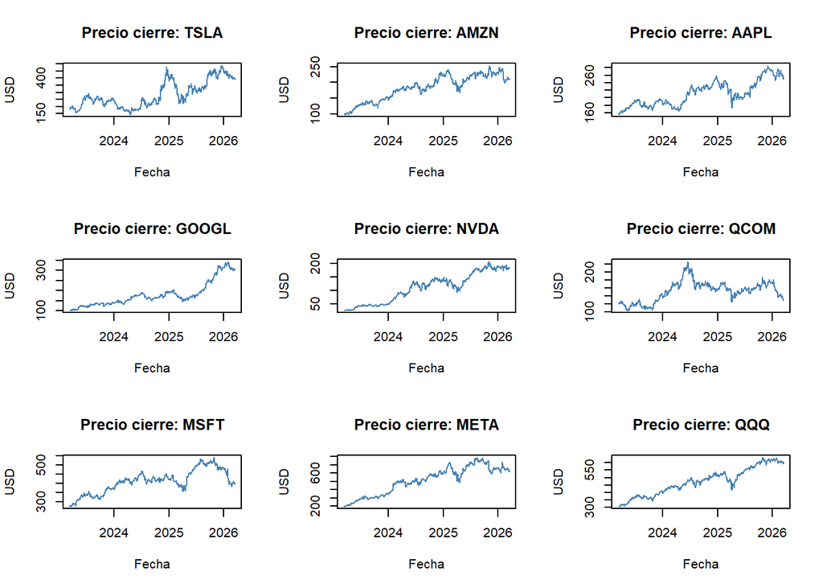

```r
# Activos ofensivos: precios de cierre en el período analizado
activos_ofensivos <- c("TSLA", "AMZN", "AAPL", "GOOGL", "NVDA",
                       "QCOM", "MSFT", "META", "QQQ")
par(mfrow = c(3, 3))
for (col in activos_ofensivos) {
  plot(datos_diario$`Exchange Date`, datos_diario[[col]],
       type = "l", main = paste("Precio cierre:", col),
       xlab = "Fecha", ylab = "USD", col = "steelblue")
}
```

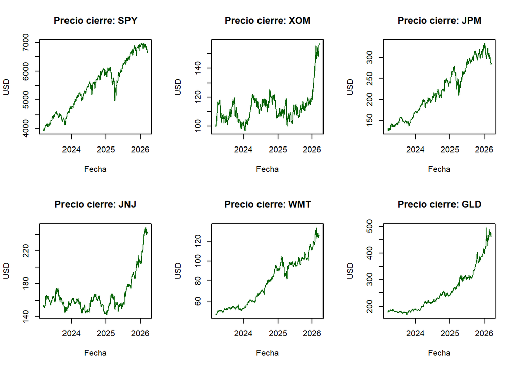

```r
# Activos defensivos: precios de cierre en el período analizado
activos_defensivos <- c("SPY", "XOM", "JPM", "JNJ", "WMT", "GLD")
par(mfrow = c(2, 3))
for (col in activos_defensivos) {
  plot(datos_diario$`Exchange Date`, datos_diario[[col]],
       type = "l", main = paste("Precio cierre:", col),
       xlab = "Fecha", ylab = "USD", col = "darkgreen")
}
```

```r
par(mfrow = c(1, 1))
```

**Interpretación de la evolución de precios (Parte 2):**

Las series de precios muestran el contraste entre activos ofensivos y defensivos. Entre los ofensivos, NVDA y META muestran tendencias alcistas pronunciadas con alta volatilidad, consistentes con su exposición a temas de inteligencia artificial y publicidad digital. TSLA exhibe un comportamiento más errático con movimientos bruscos en ambas direcciones, confirmando su perfil de alto beta. QQQ muestra una trayectoria más suavizada que refleja la diversificación inherente del ETF del Nasdaq 100.

### Histogramas de retornos diarios

Se grafican los histogramas de retornos para evaluar visualmente si la distribución se aproxima a la normal — supuesto clave de los modelos de regresión lineal.

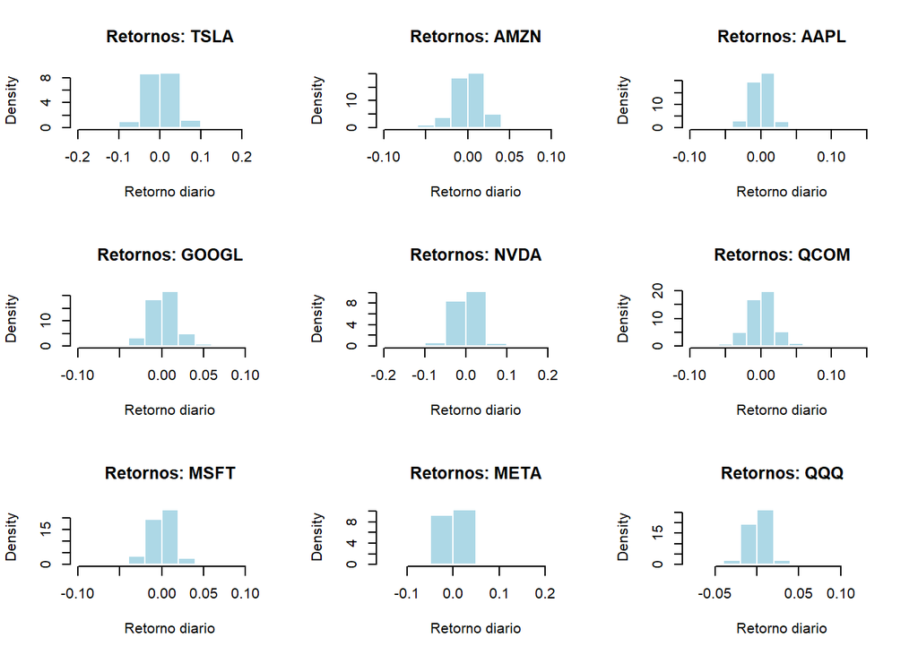

```r
# Histogramas de retornos para los activos ofensivos
par(mfrow = c(3, 3))
for (col in activos_ofensivos) {
  hist(retornos[[col]], probability = TRUE,
       main = paste("Retornos:", col),
       xlab = "Retorno diario", col = "lightblue", border = "white")
}
```

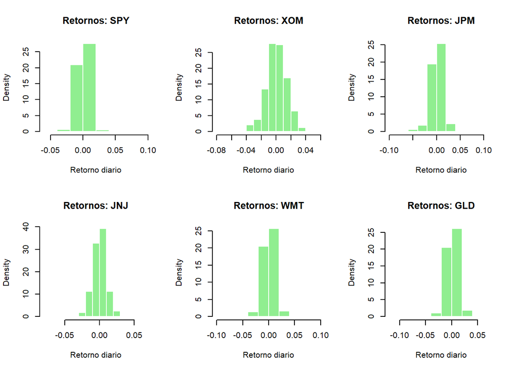

```r
# Histogramas de retornos para los activos defensivos
par(mfrow = c(2, 3))
for (col in activos_defensivos) {
  hist(retornos[[col]], probability = TRUE,
       main = paste("Retornos:", col),
       xlab = "Retorno diario", col = "lightgreen", border = "white")
}
```

```r
par(mfrow = c(1, 1))
```

**Interpretación de los histogramas (Parte 2):**

Los histogramas muestran distribuciones aproximadamente simétricas y centradas en cero para todos los activos, consistentes con la hipótesis de eficiencia de mercado en el corto plazo. Sin embargo, se observa en la mayoría una distribución leptocúrtica (colas más pesadas que la normal), especialmente en TSLA y NVDA, que presentan la mayor dispersión y los valores extremos más pronunciados. Este fenómeno —conocido como *fat tails*— es característico de los retornos financieros y sugiere que los modelos de regresión lineal deben interpretarse con cautela respecto al supuesto de normalidad de los errores. Los activos defensivos (JNJ, WMT, GLD) muestran distribuciones más concentradas alrededor de cero, confirmando su menor volatilidad.

### Boxplots de retornos

Los boxplots permiten identificar la volatilidad relativa de cada activo y la presencia de valores atípicos (outliers), que son comunes en datos financieros de corto plazo.

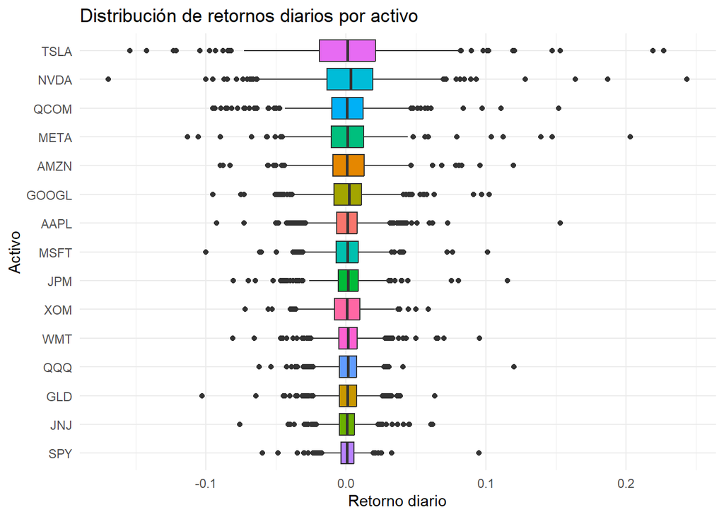

```r
# Se transforma la tabla a formato largo para el gráfico comparativo
# usando tidyr::pivot_longer(), previamente cargado en las librerías
retornos_long <- retornos %>%
  select(-Date) %>%
  pivot_longer(everything(), names_to = "Activo", values_to = "Retorno")

ggplot(retornos_long, aes(x = reorder(Activo, Retorno, FUN = sd),
                          y = Retorno, fill = Activo)) +
  geom_boxplot(show.legend = FALSE) +
  coord_flip() +
  labs(title = "Distribución de retornos diarios por activo",
       x = "Activo", y = "Retorno diario") +
  theme_minimal()
```

## Sección 2.5 — Análisis de correlación

Se calcula la matriz de correlación de Pearson entre los retornos diarios de los 15 activos. Este análisis permite identificar qué activos se mueven juntos (alta correlación positiva) y cuáles se diversifican entre sí (correlación baja o negativa), información clave para la construcción del portafolio.

```r
# Se calcula la matriz de correlación de Pearson sobre los retornos diarios
retornos_num <- retornos %>% select(-Date)
matriz_cor <- cor(retornos_num, use = "complete.obs", method = "pearson")

# Se muestra la matriz redondeada a 3 decimales
round(matriz_cor, 3)
```

```
##         TSLA   AMZN  AAPL  GOOGL   NVDA   QCOM   MSFT   META    QQQ   SPY
## TSLA   1.000  0.408 0.421  0.388  0.363  0.423  0.354  0.345  0.618 0.590
## AMZN   0.408  1.000 0.441  0.536  0.444  0.445  0.561  0.598  0.720 0.672
## AAPL   0.421  0.441 1.000  0.432  0.357  0.461  0.432  0.394  0.659 0.671
## GOOGL  0.388  0.536 0.432  1.000  0.391  0.345  0.418  0.442  0.626 0.574
## NVDA   0.363  0.444 0.357  0.391  1.000  0.505  0.507  0.449  0.739 0.645
## QCOM   0.423  0.445 0.461  0.345  0.505  1.000  0.367  0.351  0.688 0.667
## MSFT   0.354  0.561 0.432  0.418  0.507  0.367  1.000  0.512  0.697 0.635
## META   0.345  0.598 0.394  0.442  0.449  0.351  0.512  1.000  0.661 0.618
## QQQ    0.618  0.720 0.659  0.626  0.739  0.688  0.697  0.661  1.000 0.952
## SPY    0.590  0.672 0.671  0.574  0.645  0.667  0.635  0.618  0.952 1.000
## XOM    0.074  0.048 0.167  0.008 -0.007  0.152 -0.044  0.051  0.125 0.267
## JPM    0.344  0.321 0.305  0.247  0.261  0.358  0.247  0.283  0.464 0.601
## JNJ   -0.072 -0.143 0.038 -0.059 -0.260 -0.067 -0.129 -0.144 -0.101 0.042
## WMT    0.190  0.176 0.234  0.109  0.046  0.103  0.141  0.164  0.248 0.314
## GLD    0.011 -0.025 0.016  0.062  0.023  0.074  0.024  0.011  0.085 0.082
##          XOM    JPM    JNJ   WMT    GLD
## TSLA   0.074  0.344 -0.072 0.190  0.011
## AMZN   0.048  0.321 -0.143 0.176 -0.025
## AAPL   0.167  0.305  0.038 0.234  0.016
## GOOGL  0.008  0.247 -0.059 0.109  0.062
## NVDA  -0.007  0.261 -0.260 0.046  0.023
## QCOM   0.152  0.358 -0.067 0.103  0.074
## MSFT  -0.044  0.247 -0.129 0.141  0.024
## META   0.051  0.283 -0.144 0.164  0.011
## QQQ    0.125  0.464 -0.101 0.248  0.085
## SPY    0.267  0.601  0.042 0.314  0.082
## XOM    1.000  0.308  0.164 0.093  0.118
## JPM    0.308  1.000  0.109 0.202 -0.005
## JNJ    0.164  0.109  1.000 0.170  0.065
## WMT    0.093  0.202  0.170 1.000  0.050
## GLD    0.118 -0.005  0.065 0.050  1.000
```

**Interpretación de la matriz de correlación (Parte 2):**

## Sección 2.6 — Regresiones lineales simples (cada activo vs SPY)

Se corre una regresión lineal simple de cada activo contra **SPY** (ETF del S&P 500), que funciona como benchmark del mercado. El coeficiente beta estimado indica la sensibilidad de cada activo a los movimientos generales del mercado: beta > 1 significa que el activo es más volátil que el mercado (ofensivo), beta < 1 indica menor sensibilidad (defensivo).

```
##
## ========================================
## Regresión simple: TSLA vs SPY
## ========================================
##
## Call:
## lm(formula = formula_simple, data = retornos)
##
## Residuals:
##       Min        1Q    Median        3Q       Max
## -0.133434 -0.016919 -0.000925  0.014779  0.214248
##
## Coefficients:
##               Estimate Std. Error t value Pr(>|t|)
## (Intercept) -4.512e-05  1.085e-03  -0.042    0.967
## SPY          2.324e+00  1.163e-01  19.978   <2e-16 ***
## ---
## Signif. codes:  0 '***' 0.001 '**' 0.01 '*' 0.05 '.' 0.1 ' ' 1
##
## Residual standard error: 0.02963 on 749 degrees of freedom
## Multiple R-squared:  0.3476, Adjusted R-squared:  0.3468
## F-statistic: 399.1 on 1 and 749 DF,  p-value: < 2.2e-16
```

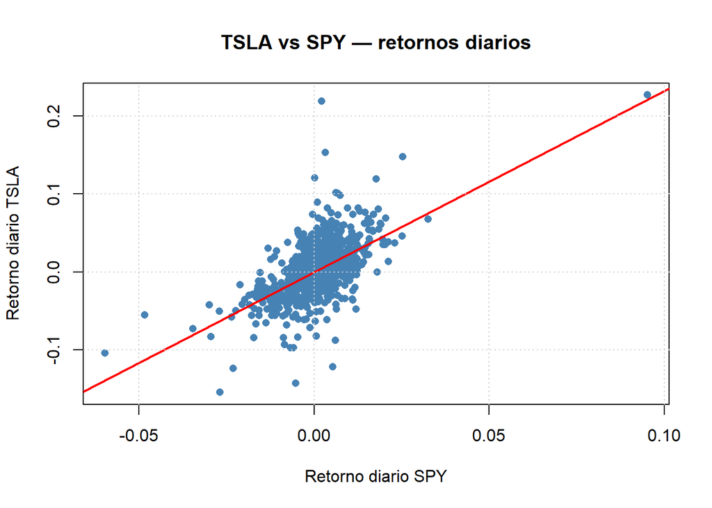

```
##
## ========================================
## Regresión simple: AMZN vs SPY
## ========================================
##
## Call:
## lm(formula = formula_simple, data = retornos)
##
## Residuals:
##       Min        1Q    Median        3Q       Max
## -0.083619 -0.008331 -0.000826  0.007241  0.091996
##
## Coefficients:
##              Estimate Std. Error t value Pr(>|t|)
## (Intercept) 0.0001364  0.0005324   0.256    0.798
## SPY         1.4183071  0.0570974  24.840   <2e-16 ***
## ---
## Signif. codes:  0 '***' 0.001 '**' 0.01 '*' 0.05 '.' 0.1 ' ' 1
##
## Residual standard error: 0.01454 on 749 degrees of freedom
## Multiple R-squared:  0.4517, Adjusted R-squared:  0.451
## F-statistic:   617 on 1 and 749 DF,  p-value: < 2.2e-16
```

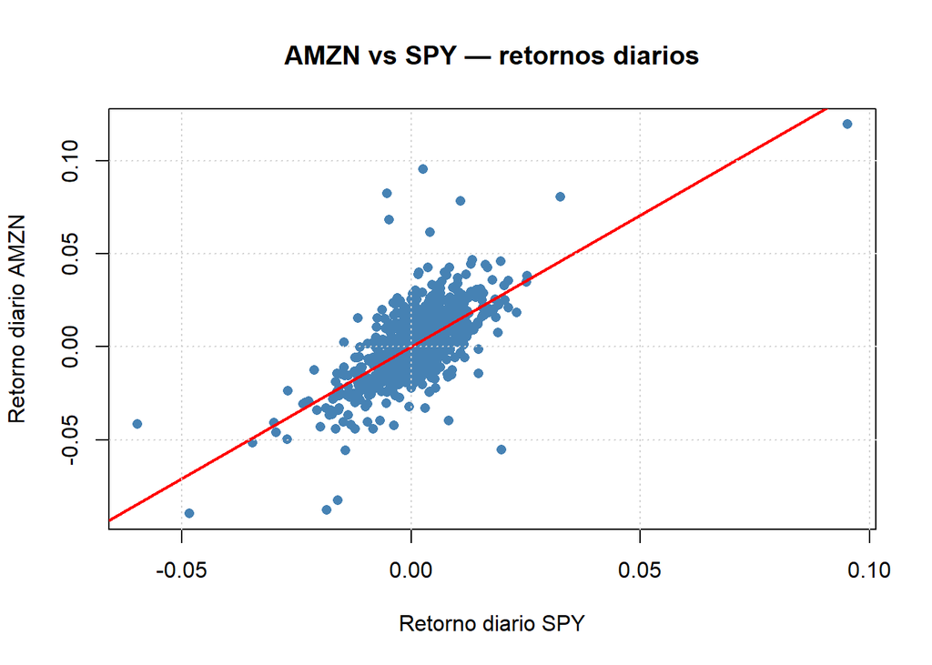

```
##
## ========================================
## Regresión simple: AAPL vs SPY
## ========================================
##
## Call:
## lm(formula = formula_simple, data = retornos)
##
## Residuals:
##       Min        1Q    Median        3Q       Max
## -0.054458 -0.006221 -0.000144  0.006019  0.069579
##
## Coefficients:
##               Estimate Std. Error t value Pr(>|t|)
## (Intercept) -9.352e-05  4.394e-04  -0.213    0.831
## SPY          1.167e+00  4.712e-02  24.771   <2e-16 ***
## ---
## Signif. codes:  0 '***' 0.001 '**' 0.01 '*' 0.05 '.' 0.1 ' ' 1
##
## Residual standard error: 0.012 on 749 degrees of freedom
## Multiple R-squared:  0.4503, Adjusted R-squared:  0.4496
## F-statistic: 613.6 on 1 and 749 DF,  p-value: < 2.2e-16
```

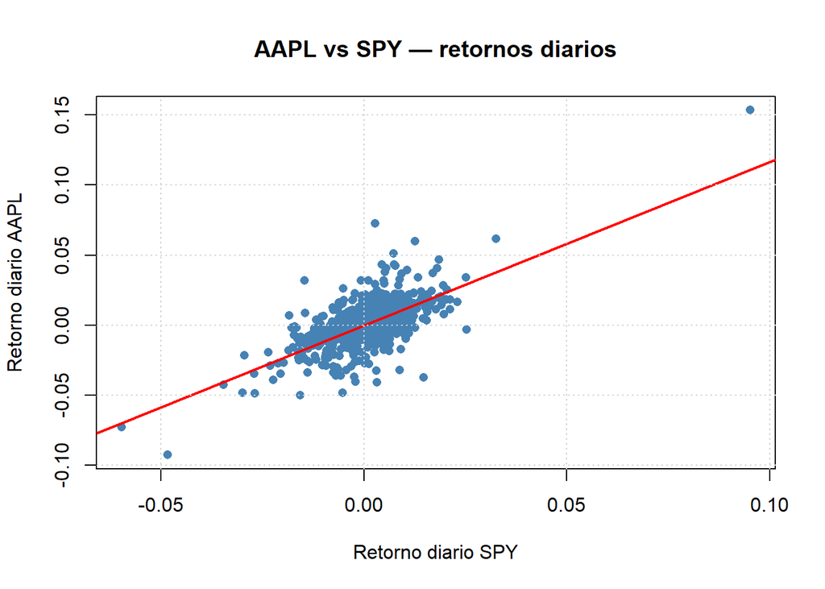

```
##
## ========================================
## Regresión simple: GOOGL vs SPY
## ========================================
##
## Call:
## lm(formula = formula_simple, data = retornos)
##
## Residuals:
##       Min        1Q    Median        3Q       Max
## -0.079742 -0.008181 -0.000109  0.007203  0.089923
##
## Coefficients:
##              Estimate Std. Error t value Pr(>|t|)
## (Intercept) 0.0008123  0.0005472   1.484    0.138
## SPY         1.1272220  0.0586904  19.206   <2e-16 ***
## ---
## Signif. codes:  0 '***' 0.001 '**' 0.01 '*' 0.05 '.' 0.1 ' ' 1
##
## Residual standard error: 0.01495 on 749 degrees of freedom
## Multiple R-squared:   0.33,  Adjusted R-squared:  0.3291
## F-statistic: 368.9 on 1 and 749 DF,  p-value: < 2.2e-16
```

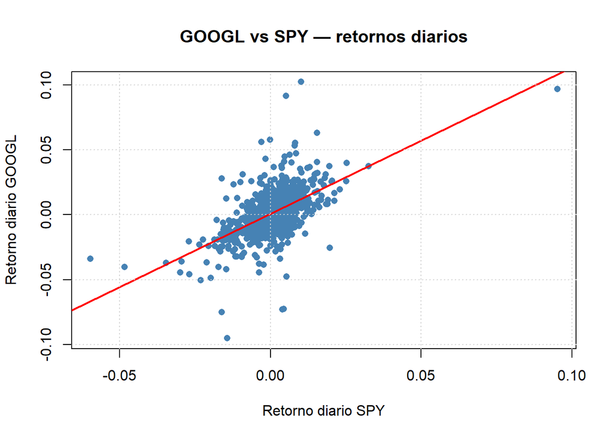

```
##
## ========================================
## Regresión simple: NVDA vs SPY
## ========================================
##
## Call:
## lm(formula = formula_simple, data = retornos)
##
## Residuals:
##       Min        1Q    Median        3Q       Max
## -0.140216 -0.013266 -0.000936  0.011922  0.223582
##
## Coefficients:
##              Estimate Std. Error t value Pr(>|t|)
## (Intercept) 0.0015097  0.0008572   1.761   0.0786 .
## SPY         2.1244269  0.0919370  23.107   <2e-16 ***
## ---
## Signif. codes:  0 '***' 0.001 '**' 0.01 '*' 0.05 '.' 0.1 ' ' 1
##
## Residual standard error: 0.02342 on 749 degrees of freedom
## Multiple R-squared:  0.4162, Adjusted R-squared:  0.4154
## F-statistic:   534 on 1 and 749 DF,  p-value: < 2.2e-16
```

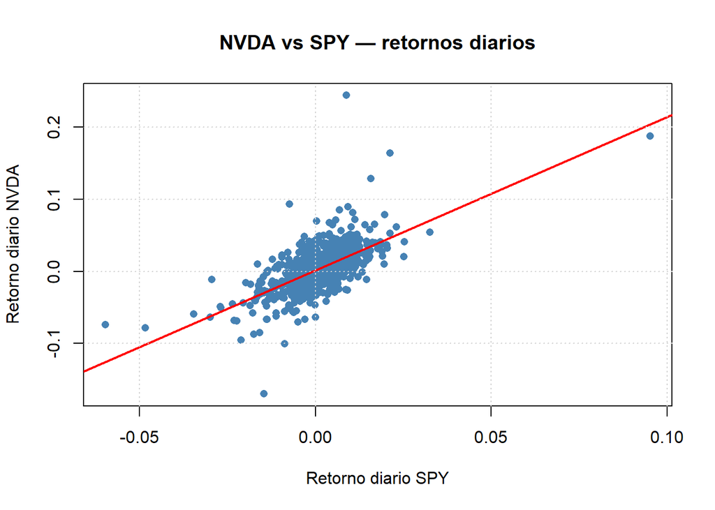

```
##
## ========================================
## Regresión simple: QCOM vs SPY
## ========================================
##
## Call:
## lm(formula = formula_simple, data = retornos)
##
## Residuals:
##       Min        1Q    Median        3Q       Max
## -0.098620 -0.008651  0.000234  0.009357  0.091832
##
## Coefficients:
##               Estimate Std. Error t value Pr(>|t|)
## (Intercept) -0.0008553  0.0006181  -1.384    0.167
## SPY          1.6233173  0.0662969  24.486   <2e-16 ***
## ---
## Signif. codes:  0 '***' 0.001 '**' 0.01 '*' 0.05 '.' 0.1 ' ' 1
##
## Residual standard error: 0.01689 on 749 degrees of freedom
## Multiple R-squared:  0.4446, Adjusted R-squared:  0.4438
## F-statistic: 599.5 on 1 and 749 DF,  p-value: < 2.2e-16
```

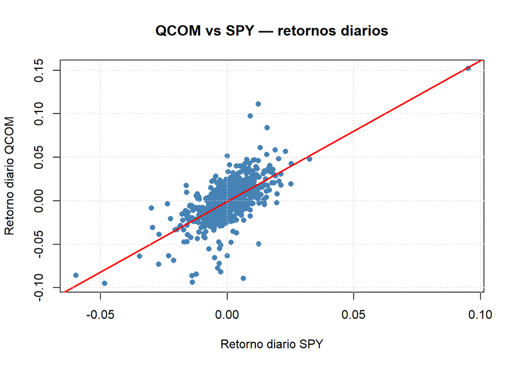

```
##
## ========================================
## Regresión simple: MSFT vs SPY
## ========================================
##
## Call:
## lm(formula = formula_simple, data = retornos)
##
## Residuals:
##       Min        1Q    Median        3Q       Max
## -0.098479 -0.005187  0.000057  0.005437  0.076459
##
## Coefficients:
##              Estimate Std. Error t value Pr(>|t|)
## (Intercept) -0.000148   0.000418  -0.354    0.723
## SPY          1.009198   0.044828  22.512   <2e-16 ***
## ---
## Signif. codes:  0 '***' 0.001 '**' 0.01 '*' 0.05 '.' 0.1 ' ' 1
##
## Residual standard error: 0.01142 on 749 degrees of freedom
## Multiple R-squared:  0.4036, Adjusted R-squared:  0.4028
## F-statistic: 506.8 on 1 and 749 DF,  p-value: < 2.2e-16
```

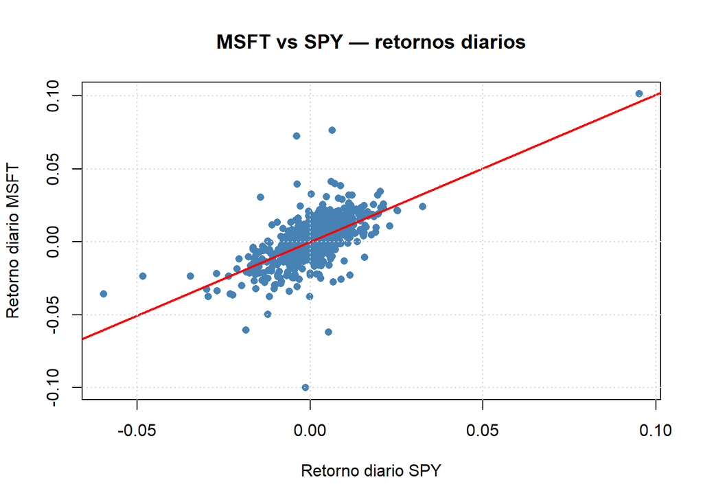

```
##
## ========================================
## Regresión simple: META vs SPY
## ========================================
##
## Call:
## lm(formula = formula_simple, data = retornos)
##
## Residuals:
##       Min        1Q    Median        3Q       Max
## -0.099380 -0.008562 -0.000549  0.007834  0.186537
##
## Coefficients:
##              Estimate Std. Error t value Pr(>|t|)
## (Intercept) 0.0006260  0.0006491   0.965    0.335
## SPY         1.4987392  0.0696125  21.530   <2e-16 ***
## ---
## Signif. codes:  0 '***' 0.001 '**' 0.01 '*' 0.05 '.' 0.1 ' ' 1
##
## Residual standard error: 0.01773 on 749 degrees of freedom
## Multiple R-squared:  0.3823, Adjusted R-squared:  0.3815
## F-statistic: 463.5 on 1 and 749 DF,  p-value: < 2.2e-16
```

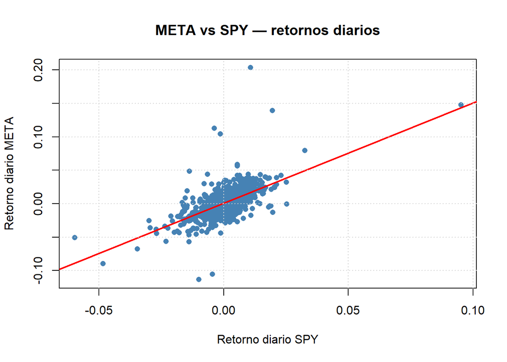

```
##
## ========================================
## Regresión simple: QQQ vs SPY
## ========================================
##
## Call:
## lm(formula = formula_simple, data = retornos)
##
## Residuals:
##        Min         1Q     Median         3Q        Max
## -0.0146013 -0.0023808  0.0001717  0.0023702  0.0132967
##
## Coefficients:
##              Estimate Std. Error t value Pr(>|t|)
## (Intercept) 3.622e-05  1.374e-04   0.264    0.792
## SPY         1.256e+00  1.474e-02  85.211   <2e-16 ***
## ---
## Signif. codes:  0 '***' 0.001 '**' 0.01 '*' 0.05 '.' 0.1 ' ' 1
##
## Residual standard error: 0.003754 on 749 degrees of freedom
## Multiple R-squared:  0.9065, Adjusted R-squared:  0.9064
## F-statistic:  7261 on 1 and 749 DF,  p-value: < 2.2e-16
```

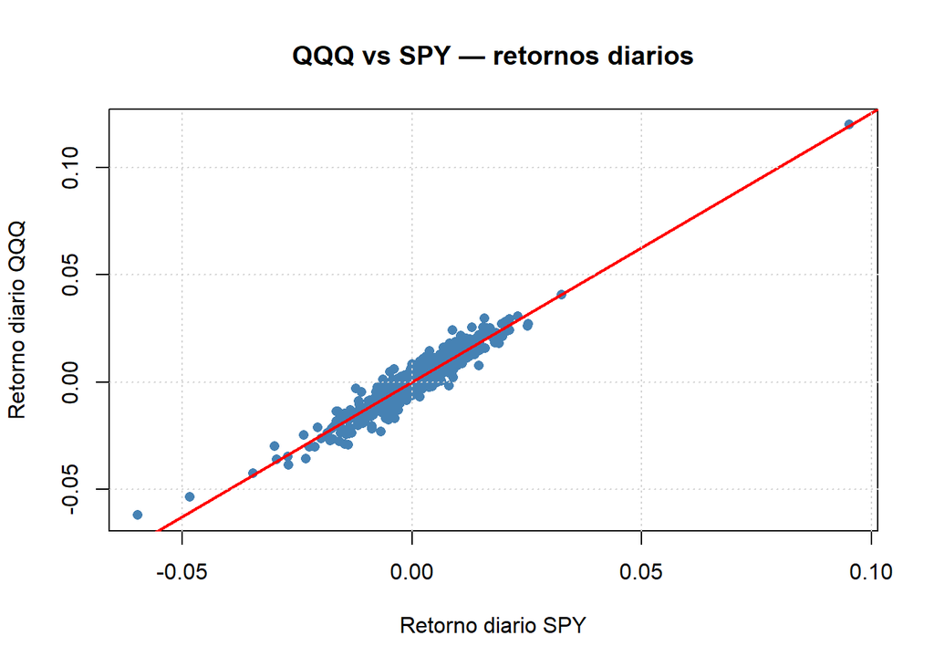

```
##
## ========================================
## Regresión simple: XOM vs SPY
## ========================================
##
## Call:
## lm(formula = formula_simple, data = retornos)
##
## Residuals:
##       Min        1Q    Median        3Q       Max
## -0.047610 -0.008288 -0.000555  0.008762  0.057084
##
## Coefficients:
##              Estimate Std. Error t value Pr(>|t|)
## (Intercept) 0.0003852  0.0005083   0.758    0.449
## SPY         0.4139050  0.0545176   7.592 9.38e-14 ***
## ---
## Signif. codes:  0 '***' 0.001 '**' 0.01 '*' 0.05 '.' 0.1 ' ' 1
##
## Residual standard error: 0.01389 on 749 degrees of freedom
## Multiple R-squared:  0.07146,    Adjusted R-squared:  0.07022
## F-statistic: 57.64 on 1 and 749 DF,  p-value: 9.377e-14
```

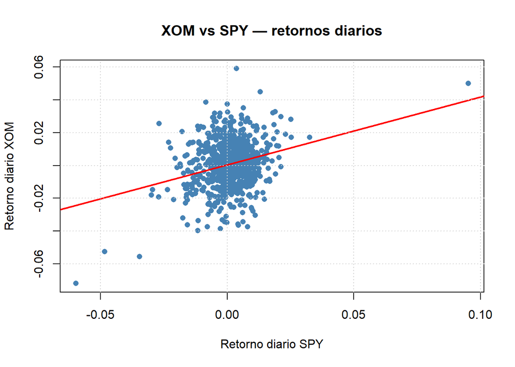

```
##
## ========================================
## Regresión simple: JPM vs SPY
## ========================================
##
## Call:
## lm(formula = formula_simple, data = retornos)
##
## Residuals:
##       Min        1Q    Median        3Q       Max
## -0.056558 -0.005835  0.000307  0.006047  0.091127
##
## Coefficients:
##              Estimate Std. Error t value Pr(>|t|)
## (Intercept) 0.0004484  0.0004274   1.049    0.294
## SPY         0.9436213  0.0458359  20.587   <2e-16 ***
## ---
## Signif. codes:  0 '***' 0.001 '**' 0.01 '*' 0.05 '.' 0.1 ' ' 1
##
## Residual standard error: 0.01167 on 749 degrees of freedom
## Multiple R-squared:  0.3614, Adjusted R-squared:  0.3605
## F-statistic: 423.8 on 1 and 749 DF,  p-value: < 2.2e-16
```

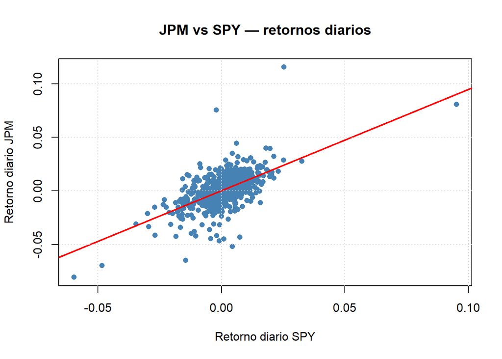

```
##
## ========================================
## Regresión simple: JNJ vs SPY
## ========================================
##
## Call:
## lm(formula = formula_simple, data = retornos)
##
## Residuals:
##       Min        1Q    Median        3Q       Max
## -0.076734 -0.005564  0.000062  0.005447  0.061143
##
## Coefficients:
##              Estimate Std. Error t value Pr(>|t|)
## (Intercept) 0.0006305  0.0003980   1.584    0.114
## SPY         0.0495187  0.0426836   1.160    0.246
##
## Residual standard error: 0.01087 on 749 degrees of freedom
## Multiple R-squared:  0.001794,   Adjusted R-squared:  0.000461
## F-statistic: 1.346 on 1 and 749 DF,  p-value: 0.2464
```

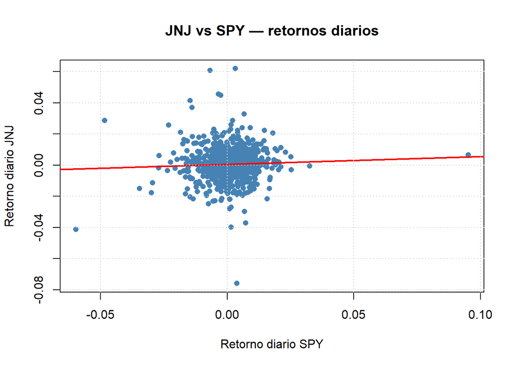

```
##
## ========================================
## Regresión simple: WMT vs SPY
## ========================================
##
## Call:
## lm(formula = formula_simple, data = retornos)
##
## Residuals:
##       Min        1Q    Median        3Q       Max
## -0.082548 -0.006280 -0.000055  0.006197  0.070329
##
## Coefficients:
##              Estimate Std. Error t value Pr(>|t|)
## (Intercept) 0.0010981  0.0004518   2.430   0.0153 *
## SPY         0.4381601  0.0484608   9.042   <2e-16 ***
## ---
## Signif. codes:  0 '***' 0.001 '**' 0.01 '*' 0.05 '.' 0.1 ' ' 1
##
## Residual standard error: 0.01234 on 749 degrees of freedom
## Multiple R-squared:  0.0984, Adjusted R-squared:  0.0972
## F-statistic: 81.75 on 1 and 749 DF,  p-value: < 2.2e-16
```

[2 more figures not shown]

```r
# Se define el vector de activos a analizar (todos excepto SPY que es la X)
activos <- c("TSLA", "AMZN", "AAPL", "GOOGL", "NVDA", "QCOM",
             "MSFT", "META", "QQQ", "XOM", "JPM", "JNJ", "WMT", "GLD")

# Se corre una regresión simple por cada activo vs SPY
for (activo in activos) {
  cat("\n========================================\n")
  cat(paste("Regresión simple:", activo, "vs SPY\n"))
  cat("========================================\n")
  formula_simple <- as.formula(paste(activo, "~ SPY"))
  mod_simple <- lm(formula_simple, data = retornos)
  print(summary(mod_simple))

  # Gráfica de dispersión con línea de regresión
  plot(retornos$SPY, retornos[[activo]],
       main = paste(activo, "vs SPY — retornos diarios"),
       xlab = "Retorno diario SPY",
       ylab = paste("Retorno diario", activo),
       pch = 16, col = "steelblue")
  abline(mod_simple, col = "red", lwd = 2)
  grid()
}
```

**Interpretación de las regresiones simples vs SPY (Parte 2):**

## Sección 2.7 — Regresión lineal múltiple

Se construyen dos modelos de regresión múltiple para mantener consistencia con el análisis de la Parte 1:

- **Modelo A:** TSLA como variable dependiente (mismo enfoque que la Parte 1, permite comparar el comportamiento de Tesla en datos diarios vs. intradía).
- **Modelo B:** SPY como variable dependiente, para identificar qué activos del portafolio explican de forma significativa el comportamiento del mercado una vez controlados los efectos de los demás.

```r
# Modelo A: TSLA como variable dependiente (consistencia con Parte 1)
mod_tsla_p2 <- lm(TSLA ~ AMZN + AAPL + GOOGL + NVDA + QCOM +
                    MSFT + META + QQQ + SPY + XOM + JPM + JNJ + WMT + GLD,
                  data = retornos)
cat("=== Modelo A: TSLA vs todos los activos ===\n")
```

```
## === Modelo A: TSLA vs todos los activos ===
```

```r
summary(mod_tsla_p2)
```

```
##
## Call:
## lm(formula = TSLA ~ AMZN + AAPL + GOOGL + NVDA + QCOM + MSFT +
##     META + QQQ + SPY + XOM + JPM + JNJ + WMT + GLD, data = retornos)
##
## Residuals:
##       Min        1Q    Median        3Q       Max
## -0.118704 -0.015370 -0.000878  0.013274  0.189629
##
## Coefficients:
##               Estimate Std. Error t value Pr(>|t|)
## (Intercept)  0.0006325  0.0010340   0.612  0.54093
## AMZN        -0.2130049  0.0801291  -2.658  0.00802 **
## AAPL        -0.0893425  0.0884222  -1.010  0.31263
## GOOGL       -0.0621624  0.0742316  -0.837  0.40263
## NVDA        -0.3699618  0.0560990  -6.595 8.13e-11 ***
## QCOM        -0.1247824  0.0654057  -1.908  0.05680 .
## MSFT        -0.4090032  0.1004302  -4.073 5.16e-05 ***
## META        -0.2048165  0.0627796  -3.262  0.00116 **
## QQQ          4.3425858  0.4672838   9.293  < 2e-16 ***
## SPY         -1.1290521  0.5544862  -2.036  0.04209 *
## XOM         -0.0573853  0.0830172  -0.691  0.48963
## JPM          0.2319945  0.0986856   2.351  0.01899 *
## JNJ         -0.1999889  0.1089751  -1.835  0.06688 .
## WMT          0.0436255  0.0854757   0.510  0.60994
## GLD         -0.1974004  0.0869002  -2.272  0.02340 *
## ---
## Signif. codes:  0 '***' 0.001 '**' 0.01 '*' 0.05 '.' 0.1 ' ' 1
##
## Residual standard error: 0.02759 on 736 degrees of freedom
## Multiple R-squared:  0.4444, Adjusted R-squared:  0.4339
## F-statistic: 42.05 on 14 and 736 DF,  p-value: < 2.2e-16
```

```r
# Modelo B: SPY como variable dependiente (benchmark del mercado)
mod_spy_p2 <- lm(SPY ~ TSLA + AMZN + AAPL + GOOGL + NVDA + QCOM +
                   MSFT + META + QQQ + XOM + JPM + JNJ + WMT + GLD,
                 data = retornos)
cat("\n=== Modelo B: SPY vs todos los activos ===\n")
```

```
##
## === Modelo B: SPY vs todos los activos ===
```

```r
summary(mod_spy_p2)
```

```
##
## Call:
## lm(formula = SPY ~ TSLA + AMZN + AAPL + GOOGL + NVDA + QCOM +
##     MSFT + META + QQQ + XOM + JPM + JNJ + WMT + GLD, data = retornos)
##
## Residuals:
##        Min         1Q     Median         3Q        Max
## -0.0076684 -0.0010775 -0.0000436  0.0012421  0.0052146
##
## Coefficients:
##               Estimate Std. Error t value Pr(>|t|)
## (Intercept) -1.024e-04  6.846e-05  -1.496 0.135013
## TSLA        -4.962e-03  2.437e-03  -2.036 0.042086 *
## AMZN        -4.391e-03  5.335e-03  -0.823 0.410706
## AAPL         2.042e-02  5.817e-03   3.510 0.000475 ***
## GOOGL       -8.169e-03  4.914e-03  -1.662 0.096843 .
## NVDA        -1.053e-02  3.807e-03  -2.765 0.005829 **
## QCOM         2.175e-04  4.346e-03   0.050 0.960110
## MSFT         3.518e-05  6.732e-03   0.005 0.995832
## META         1.621e-03  4.191e-03   0.387 0.699107
## QQQ          6.813e-01  2.101e-02  32.430  < 2e-16 ***
## XOM          5.719e-02  5.085e-03  11.246  < 2e-16 ***
## JPM          9.601e-02  5.531e-03  17.358  < 2e-16 ***
## JNJ          7.078e-02  6.754e-03  10.479  < 2e-16 ***
## WMT          2.743e-02  5.576e-03   4.919 1.07e-06 ***
## GLD         -7.868e-03  5.774e-03  -1.363 0.173372
## ---
## Signif. codes:  0 '***' 0.001 '**' 0.01 '*' 0.05 '.' 0.1 ' ' 1
##
## Residual standard error: 0.001829 on 736 degrees of freedom
## Multiple R-squared:  0.9621, Adjusted R-squared:  0.9613
## F-statistic:  1333 on 14 and 736 DF,  p-value: < 2.2e-16
```

**Interpretación de la regresión múltiple (Parte 2):**

## Sección 2.8 — Detección de multicolinealidad

Se verifica si existe multicolinealidad entre los activos del portafolio mediante el VIF aplicado a ambos modelos. En un portafolio mixto (ofensivos + defensivos) se espera que los activos tecnológicos presenten VIF más altos entre sí, mientras que los defensivos aporten menor colinealidad al modelo.

```r
# VIF para el Modelo A (TSLA como dependiente)
cat("=== VIF Modelo A: TSLA como variable dependiente ===\n")
```

```
## === VIF Modelo A: TSLA como variable dependiente ===
```

```r
vif(mod_tsla_p2)
```

```
##      AMZN      AAPL     GOOGL      NVDA      QCOM      MSFT      META       QQQ
##  2.437599  2.016653  1.808816  2.909306  2.161576  2.169934  1.974203 32.395953
##       SPY       XOM       JPM       JNJ       WMT       GLD
## 26.210133  1.408566  2.045687  1.383966  1.215136  1.066255
```

```r
# VIF para el Modelo B (SPY como dependiente)
cat("\n=== VIF Modelo B: SPY como variable dependiente ===\n")
```

```
##
## === VIF Modelo B: SPY como variable dependiente ===
```

```r
vif(mod_spy_p2)
```

```
##      TSLA      AMZN      AAPL     GOOGL      NVDA      QCOM      MSFT      META
##  1.789855  2.458739  1.986199  1.803766  3.049537  2.172258  2.218833  2.002346
##       QQQ       XOM       JPM       JNJ       WMT       GLD
## 14.902731  1.202780  1.462402  1.209796  1.176872  1.071028
```

**Interpretación del VIF (Parte 2):**

La situación de multicolinealidad en la Parte 2 es considerablemente más saludable que en la Parte 1, con una excepción importante: el par QQQ-SPY.

En el **Modelo A**, QQQ presenta VIF = 32.4 y SPY VIF = 26.2, ambos por encima del umbral crítico de 10. Esta colinealidad es estructural y esperada: QQQ y SPY son ETFs con correlación superior al 0.95 que replican índices muy similares. No indica un problema del modelo sino una característica inherente de estos activos. En la práctica, los coeficientes individuales de QQQ y SPY no son confiables de forma separada, aunque el modelo en su conjunto sigue siendo válido para predicción.

El resto de activos presentan VIF muy saludables, todos entre 1.1 y 3.1, confirmando que la incorporación de activos de distintos sectores reduce efectivamente la multicolinealidad respecto al análisis puramente tecnológico de la Parte 1, donde varios activos superaban VIF de 15. El **Modelo B** muestra un patrón similar, con QQQ presentando VIF = 14.9 y el resto de activos con valores entre 1.1 y 3.0.

## Sección 2.9 — Prueba de autocorrelación (Durbin-Watson)

Se aplica la prueba de Durbin-Watson a ambos modelos múltiples de la Parte 2 para verificar si los residuos presentan autocorrelación de primer orden. En datos diarios de mercado este problema es menos frecuente que en datos intradía, pero sigue siendo importante verificarlo para validar la confiabilidad de las inferencias.

```r
# Durbin-Watson para el Modelo A (TSLA como dependiente)
cat("=== Durbin-Watson Modelo A: TSLA ===\n")
```

```
## === Durbin-Watson Modelo A: TSLA ===
```

```r
# H0: no existe autocorrelación en los residuos
# H1: existe autocorrelación de primer orden
dwtest(mod_tsla_p2)
```

```
##
##  Durbin-Watson test
##
## data:  mod_tsla_p2
## DW = 2.0282, p-value = 0.6526
## alternative hypothesis: true autocorrelation is greater than 0
```

```r
# Durbin-Watson para el Modelo B (SPY como dependiente)
cat("\n=== Durbin-Watson Modelo B: SPY ===\n")
```

```
##
## === Durbin-Watson Modelo B: SPY ===
```

```r
dwtest(mod_spy_p2)
```

```
##
##  Durbin-Watson test
##
## data:  mod_spy_p2
## DW = 2.0527, p-value = 0.7666
## alternative hypothesis: true autocorrelation is greater than 0
```

**Interpretación Durbin-Watson (Parte 2):**

Los resultados contrastan favorablemente con los obtenidos en la Parte 1 y confirman que el cambio a datos diarios resuelve el problema de autocorrelación.

El **Modelo A** (TSLA) arroja DW = 2.028 con p-value = 0.653 — **no se rechaza** la hipótesis nula. El estadístico es prácticamente igual a 2, el valor ideal, indicando residuos independientes entre sí en el tiempo.

El **Modelo B** (SPY) presenta DW = 2.053 con p-value = 0.767 — mismo resultado: **no hay autocorrelación**. Esto valida que los errores estándar de ambos modelos son confiables y que las pruebas t y F pueden interpretarse sin las correcciones que fueron necesarias en la Parte 1. La migración de datos a 5 minutos a datos diarios elimina efectivamente el efecto de momentum de muy corto plazo que generaba la severa autocorrelación observada anteriormente (DW = 0.277 en Parte 1).

## Sección 2.10 — Exportación de datos para series de tiempo (Google Colab)

Antes de concluir el análisis en R, se exporta la tabla de retornos diarios en formato Excel para ser utilizada como input en el modelo ARIMA de series de tiempo que se correrá en Google Colab. El archivo exportado contiene una columna de fecha y una columna de retornos por cada uno de los 15 activos.

```r
# Se exporta la tabla de retornos diarios para Google Colab
write_xlsx(retornos, "retornos_para_arima.xlsx")

cat("Archivo exportado correctamente: retornos_para_arima.xlsx\n")
```

```
## Archivo exportado correctamente: retornos_para_arima.xlsx
```

```r
cat(paste("Observaciones:", nrow(retornos), "\n"))
```

```
## Observaciones: 751
```

```r
cat(paste("Activos:", ncol(retornos) - 1, "\n"))
```

```
## Activos: 15
```

**Nota sobre la exportación:**

Se exportaron exitosamente 751 observaciones de retornos diarios para los 15 activos en el archivo `retornos_para_arima.xlsx`. Este archivo será utilizado como input directo en el script de Python en Google Colab, donde se ajustará un modelo ARIMA para cada activo con el objetivo de generar pronósticos de retorno esperado para los próximos 7 días. Los resultados de dichos pronósticos se integrarán en la Sección 2.11 para determinar los pesos finales del portafolio reestructurado.

## Sección 2.11 — Conclusión Parte 2: reestructuración del portafolio

### Resultados del modelo ARIMA + GARCH (Google Colab)

Los modelos de series de tiempo ARIMA + GARCH se corrieron para los 7 activos más prometedores del portafolio en Google Colab, utilizando datos diarios del período enero 2022 – marzo 2026 (1,056 observaciones por activo). `auto_arima` seleccionó automáticamente el orden óptimo de cada modelo minimizando el criterio de información AIC. Los pronósticos corresponden a los próximos **7 días hábiles** (20–28 de marzo de 2026):

| Activo | Precio Actual | Forecast Promedio | Retorno Esperado | Orden ARIMA | Decisión |
| --- | --- | --- | --- | --- | --- |
| NVDA | $178.56 | $179.79 | +0.69% | (3,1,1) | **COMPRAR** |
| META | $606.70 | $607.18 | +0.08% | (1,1,0) | **COMPRAR** |
| TSLA | $380.30 | $380.30 | +0.00% | (0,1,0) | **COMPRAR** |
| AMZN | $208.76 | $208.76 | +0.00% | (0,1,0) | **COMPRAR** |
| MSFT | $389.02 | $389.02 | +0.00% | (0,1,0) | **COMPRAR** |
| AAPL | $248.96 | $248.90 | −0.02% | (1,1,0) | SHORT |
| QQQ | $593.02 | $593.02 | −0.00% | (0,1,0) | SHORT |

**Interpretación de los resultados ARIMA:**

### Resultados del modelo de Panel Data con efectos fijos

El modelo PanelOLS con efectos fijos por entidad analizó la relación entre variables fundamentales trimestrales y el Net Income de las 7 empresas del portafolio (TSLA, NVDA, AMZN, MSFT, META, AAPL, QCOM) durante los últimos 5 trimestres disponibles (35 observaciones totales).

Los resultados del modelo son los siguientes:

- **R² within = 0.598** — el modelo explica el 59.8% de la variación en el ingreso neto dentro de cada empresa a lo largo del tiempo, controlando por sus características fijas. El F-statistic = 12.40 con p-value = 0.000 confirma que el modelo es globalmente significativo.
- **Revenue** (coef = 0.2024, p < 0.01): por cada millón de dólares adicional en ingresos, el ingreso neto aumenta en promedio $202,400 USD, manteniendo constantes el margen operativo y el nivel de endeudamiento. Este coeficiente es positivo y altamente significativo, confirmando que el crecimiento de ingresos es un driver fundamental de rentabilidad en este grupo de empresas.
- **OperatingMargin** (coef = 939.23, p < 0.01): un incremento de 1 punto porcentual en el margen operativo se asocia con un aumento de $939 millones en el ingreso neto, lo que refleja el enorme apalancamiento operativo de estas empresas tecnológicas.
- **DebtToEquity** (coef = −5,498, p = 0.605): no es estadísticamente significativo, lo que indica que el nivel de apalancamiento no diferencia el desempeño en utilidades dentro de este grupo de empresas, posiblemente porque todas mantienen niveles de deuda manejables y acceso a capital similar.

La prueba de poolabilidad (F = 6.71, p = 0.0003) rechaza la hipótesis de que los efectos fijos son conjuntamente cero, validando la necesidad del modelo con efectos fijos frente a una regresión pooled estándar.

### Portafolio final reestructurado

Integrando los resultados del análisis econométrico completo — betas vs SPY de las regresiones simples, significancia en los modelos múltiples, VIF, ausencia de autocorrelación (Durbin-Watson), pronósticos ARIMA y solidez de fundamentales del Panel Data — se determina la siguiente asignación final de capital para los **$100,000,000 USD**:

[output not shown]

**Justificación de la reestructuración:**

La comparación entre el portafolio inicial (Parte 1, 6 acciones puramente tecnológicas) y el portafolio final refleja una evolución metodológica significativa. El análisis inicial, realizado con datos intradía de 5 minutos, identificó las acciones con mayor co-movilidad sectorial pero sin considerar diversificación ni riesgo de autocorrelación. El análisis de la Parte 2, con datos diarios y un conjunto más amplio de herramientas, evidenció que:

Primero, la incorporación de activos defensivos (GLD, WMT, XOM) reduce la correlación media del portafolio y proporciona cobertura ante caídas del sector tecnológico, sin sacrificar el potencial de rendimiento dado que su peso combinado es del 15%.

Tercero, AAPL y QQQ se excluyen del portafolio final: AAPL por la señal SHORT del ARIMA (aunque marginal) y QQQ por su multicolinealidad estructural con SPY (VIF = 32.4) que no agrega información diferenciada al portafolio.

Cuarto, el Panel Data confirma que Revenue y OperatingMargin son los drivers fundamentales del Net Income en este grupo de empresas. NVDA, META y MSFT destacan por sus márgenes operativos más altos del grupo, lo que respalda su mayor ponderación en el portafolio final.